# 管道操作和用函数替代操作符

magrittr 包

Humoon

2021-02-26

# 1 基本应用

把前一个表达式（函数）的输出直接传递给后面的函数或者表达式，省去不必要中间变量或者括号,使代码更加清晰易读。

一个标准：一行只做一件事，尽量少定义变量！

## 1.1 `%>%` 管道操作符

传递结果给右边的函数或表达式

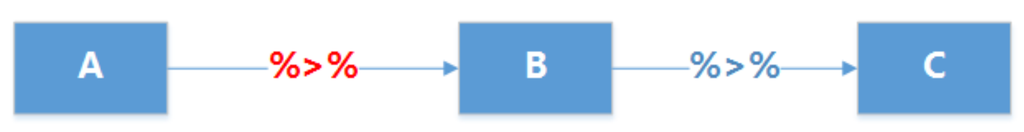

```r
set.seed(123)
rnorm(10) %>% `*`(5) %>% `+`(5) # `*`和`+`就像两个函数
```

```
 [1]  2.198  3.849 12.794  5.353  5.646 13.575  7.305 -1.325  1.566  2.772
```

## 1.2 `%T>%` T 管道操作符

必须与`%>%`配合使用。

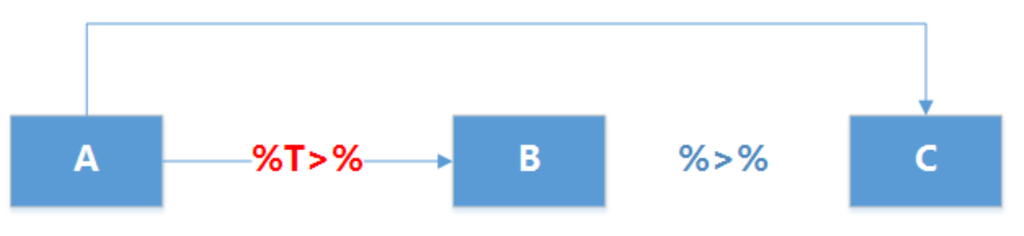

例1：在数据处理的中间过程，需要打印输出或图片输出（如观察代码是否达到了预设的目的），这时整个过程就会被中断，用向左操作符就可以解决这样的问题。

```
 num [1:50, 1:2] 1.224 0.36 0.401 0.111 -0.556 ...
```

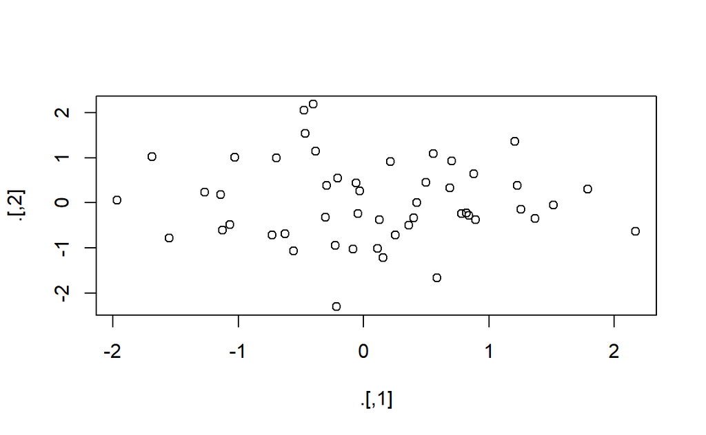

```r
rnorm(100) %>%
  matrix(ncol = 2) %T>%
  plot() %>%
  str()
```

## 1.3 `%$%` 爆炸操作符

一些基础函数只接受向量作为参数，而不接受数据框，爆炸操作符可以将参数中的$提取出来，让右侧的函数可以直接使用列名操作数据

```r
mtcars %$% cor(disp, mpg)
```

```
[1] -0.8476
```

相当于

```r
cor(mtcars$disp, mtcars$mpg)
```

```
[1] -0.8476
```

## 1.4 `%<>%` 复合赋值操作符

功能与`%>%`基本一样，多了一项额外的操作，就是把结果写到左侧对象。比如，我们需要对一个数据集进行排序，同时需要获得排序的结果，用`%<>%`就是非常方便的。

现实原理如下图所示，使用`%<>%`把左侧的数据集A传递右侧的B函数，B函数的结果数据集再向右侧传递给C函数，C函数结果的数据集再重新赋值给A，完成整个过程。

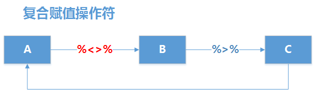

例：定义符合正态分布的100个随机数，计算绝对值，并按从小到大的顺序排序，获得并取前10个数字赋值给x。

```r
set.seed(1)
x <- rnorm(100)
a <- x %>% abs %>% sort %>% head(10)
a
```

```
 [1] 0.001105 0.016190 0.028002 0.039240 0.044934 0.053805 0.056129 0.059313
 [9] 0.074341 0.074565
```

```r
x %<>% abs %>% sort %>% head(10)
x
```

```
 [1] 0.001105 0.016190 0.028002 0.039240 0.044934 0.053805 0.056129 0.059313
 [9] 0.074341 0.074565
```

`%<>%`的主要作用是省略一步`<-`，但会造成变量的改变，程序的健壮性会因此削弱，如果不是中间变量已经太多不想再命名中间变量，最好不要用。

# 2 扩展功能

## 2.1 用函数代替操作符

| 新函数 | 原操作符 |
| --- | --- |
| `extract()` | `[` |
| `extract2()` | `[[` |
| `inset()` | `[<-` |
| `inset2()` | `[[<-` |
| `set_colnames()` | `colnames()<-` |
| `set_rownames()` | `rownames()<-` |
| use_series | `$` |
| add | `+` |
| subtract | `-` |
| multiply_by | `*` |
| raise_to_power | `^` |
| multiply_by_matrix | `%*%` |
| divide_by | `/` |
| divide_by_int | `%/%` |
| mod | `%%` |
| is_in | `%in%` |
| and | `&` |
| or | `\|` |
| equals | `==` |
| is_greater_than | `>` |
| is_weakly_greater_than | `>=` |
| is_less_than | `<` |
| is_weakly_less_than | `<=` |
| not | `!` |
| set_names | `names()<-` |

```r
set.seed(1)
x <- rnorm(10)
x
```

```
 [1] -0.6265  0.1836 -0.8356  1.5953  0.3295 -0.8205  0.4874  0.7383  0.5758
[10] -0.3054
```

```r
x %>% multiply_by(5) %>% add(5) # 替代`*`和`+`
```

```
 [1]  1.8677  5.9182  0.8219 12.9764  6.6475  0.8977  7.4371  8.6916  7.8789
[10]  3.4731
```

```r
x %<>% set_names(letters[1:10]) # 替代names(x) <-
x
```

```
      a       b       c       d       e       f       g       h       i       j
-0.6265  0.1836 -0.8356  1.5953  0.3295 -0.8205  0.4874  0.7383  0.5758 -0.3054
```

```r
y <- list(c(1,2), c('a','b'))
y %>% `[`(2)
```

```
[[1]]
[1] "a" "b"
```

```r
# 不能直接用extract()，已被其他包同名函数覆盖
y %>% magrittr::extract(2)
```

```
[[1]]
[1] "a" "b"
```

```r
y %>% extract2(2)
```

```
[1] "a" "b"
```

```r
y %>% extract2(2) %>% extract2(2)
```

```
[1] "b"
```

```r
y %>% map(extract2, 2) %>% unlist()
```

```
[1] "2" "b"
```

```r
df <- tibble(v1 = 1:26, v2 = letters)
DT::datatable(df)
```

|  | v1 | v2 |
| --- | --- | --- |
| 1 | 1 | a |
| 2 | 2 | b |
| 3 | 3 | c |
| 4 | 4 | d |
| 5 | 5 | e |
| 6 | 6 | f |
| 7 | 7 | g |
| 8 | 8 | h |
| 9 | 9 | i |
| 10 | 10 | j |

[output cut: 16 more lines]

```r
# 完成了列名赋值工作
df %<>% set_colnames(c('id','name')) %>%
  filter(id %>% is_in(1:10)) # 替代 %in%
DT::datatable(df)
```

|  | id | name |
| --- | --- | --- |
| 1 | 1 | a |
| 2 | 2 | b |
| 3 | 3 | c |
| 4 | 4 | d |
| 5 | 5 | e |
| 6 | 6 | f |
| 7 | 7 | g |
| 8 | 8 | h |
| 9 | 9 | i |
| 10 | 10 | j |

## 2.2 用 `%>%` 传递参数到代码块`{}`完成比较复杂的操作

```r
set.seed(1)

rnorm(10) %>% multiply_by(5) %>% add(5) %>%
  {
    cat("Mean:", mean(.), "\nVar:", var(.), "\n")
    sort(.) %>% head()
  }
```

```
Mean: 5.661
Var: 15.23
```

```
[1] 0.8219 0.8977 1.8677 3.4731 5.9182 6.6475
```

## 2.3 `%>%`传递到未定义的函数

函数`function(parameter){...}`外面还要用括号`()`括起来

```r
iris %>% (function(x) {
  if (nrow(x) > 2)
    bind_rows(head(x, 1), tail(x, 1)) %>% return()
  else x %>% return()
}) %>% DT::datatable()
```

|  | Sepal.Length | Sepal.Width | Petal.Length | Petal.Width | Species |
| --- | --- | --- | --- | --- | --- |
| 1 | 5.1 | 3.5 | 1.4 | 0.2 | setosa |
| 2 | 5.9 | 3 | 5.1 | 1.8 | virginica |